# NLP_Assignment_2024ct05034

All Imported Libraries

```python
import pandas as pd
import re
import random
import nltk
import spacy
import matplotlib.pyplot as plt
from spacy import displacy
from wordcloud import WordCloud
from nltk.corpus import words, treebank
from nltk.tag import hmm
from nltk.stem import PorterStemmer, WordNetLemmatizer
from sklearn.feature_extraction.text import (
    ENGLISH_STOP_WORDS,
    TfidfVectorizer,
    CountVectorizer
)
from sklearn.model_selection import train_test_split
from sklearn.tree import DecisionTreeClassifier
from sklearn.metrics import (
    accuracy_score,
    confusion_matrix,
    ConfusionMatrixDisplay,
    classification_report
)
```

1. Downloaded the dataset and created a dataframe named as food then check the head, info, and describe methods on created dataframe food

```python
file_id = "1x0oiWyLUns9002jTDj2CzIE6yqbglN__"
download_url = f"https://drive.google.com/uc?id={file_id}"


output_file = "Reviews.csv"
gdown.download(download_url, output_file, quiet=False)


food = pd.read_csv(output_file)

food = food.sample(frac=0.5, random_state=42).reset_index(drop=True)


print(" Head of dataset:")
print(food.head(), "\n")

print("Info of dataset:")
food.info()
print("\n")

print(" Numeric Summary:\n")
print(food.describe(include=['number']).round(2))

print("\n Text Summary:\n")
print(food.describe(include=['object']))
```

```
Downloading...
From (original): https://drive.google.com/uc?id=1x0oiWyLUns9002jTDj2CzIE6yqbglN__
From (redirected): https://drive.google.com/uc?id=1x0oiWyLUns9002jTDj2CzIE6yqbglN__&confirm=t&uuid=06ad7576-ce2c-4a7d-b876-647c59468873
To: /content/Reviews.csv
```

```
 Head of dataset:
       Id   ProductId          UserId             ProfileName  \
0  165257  B000EVG8J2  A1L01D2BD3RKVO  B. Miller "pet person"
1  231466  B0000BXJIS  A3U62RE5XZDP0G                   Marty
2  427828  B008FHUFAU   AOXC0JQQZGGB6         Kenneth Shevlin
3  433955  B006BXV14E  A3PWPNZVMNX3PA             rareoopdvds
4   70261  B007I7Z3Z0  A1XNZ7PCE45KK7                  Og8ys1

   HelpfulnessNumerator  HelpfulnessDenominator  Score        Time  \
0                     0                       0      5  1268179200
1                     0                       0      5  1298937600
2                     0                       2      3  1224028800
3                     0                       1      2  1335312000
4                     0                       2      5  1334707200

                                        Summary  \
0  Crunchy & Good Gluten-Free Sandwich Cookies!
1                            great kitty treats
2                                  COFFEE TASTE
3              So the Mini-Wheats were too big?
4                             Great Taste . . .

                                                Text
0  Having tried a couple of other brands of glute...
1  My cat loves these treats. If ever I can't fin...
2  A little less than I expected.  It tends to ha...
3  First there was Frosted Mini-Wheats, in origin...
4  and I want to congratulate the graphic artist ...

Info of dataset:
<class 'pandas.core.frame.DataFrame'>
RangeIndex: 284227 entries, 0 to 284226
Data columns (total 10 columns):
 #   Column                  Non-Null Count   Dtype
---  ------                  --------------   -----
 0   Id                      284227 non-null  int64
 1   ProductId               284227 non-null  object
 2   UserId                  284227 non-null  object
 3   ProfileName             284212 non-null  object
 4   HelpfulnessNumerator    284227 non-null  int64
```

[output cut: 29 more lines]

```
max    1.351210e+09

 Text Summary:

         ProductId          UserId       ProfileName     Summary  \
count       284227          284227            284212      284210
unique       54794          157688            137684      169731
top     B007JFMH8M  A3OXHLG6DIBRW8  C. F. Hill "CFH"  Delicious!
freq           448             215               218        1241

                                                     Text
count                                              284227
unique                                             218218
top     This review will make me sound really stupid, ...
freq                                                  113
```

2. Create another dataframe named Review with Score and Text column. Perform pre-processing steps like Removing Punctuations, Numbers, Special Characters, and Stop Words.

```python
nltk.download('words')

Review = food.loc[:, ['Score', 'Text']].copy()
y
stop_words = set(ENGLISH_STOP_WORDS)
english_vocab = set(w.lower() for w in words.words())


def preprocess_text(sentence: str) -> str:

    sentence = str(sentence).lower()
    sentence = re.sub(r'[^a-z\s]', ' ', sentence)
    tokens = [
        word
        for word in sentence.split()
        if (
            word not in stop_words
            and len(word) > 2
            and word in english_vocab
        )
    ]

    return " ".join(tokens).strip()

Review['cleaned_review'] = Review['Text'].apply(preprocess_text)
print("Review dataframe after preprocessing")
print(Review.head())
```

```
Review dataframe after preprocessing
   Score                                               Text  \
0      5  Having tried a couple of other brands of glute...
1      5  My cat loves these treats. If ever I can't fin...
2      3  A little less than I expected.  It tends to ha...
3      2  First there was Frosted Mini-Wheats, in origin...
4      5  and I want to congratulate the graphic artist ...

                                      cleaned_review
0  tried couple gluten free sandwich best bunch c...
1  cat house just pop come treat like crunchy per...
2           little muddy taste said favorite company
3  frosted original size frosted bite size reason...
4  want congratulate graphic artist entire produc...
```

3. Normalizing review by using Stemming or Lemmatization.

```python
nltk.download('wordnet')
nltk.download('omw-1.4')

stemmer = PorterStemmer()
lemmatizer = WordNetLemmatizer()

def normalize(text):
    return " ".join([lemmatizer.lemmatize(word) for word in text.split()])

Review['cleaned_review'] = Review['cleaned_review'].apply(normalize)
print(Review.head())
```

```
   Score                                               Text  \
0      5  Having tried a couple of other brands of glute...
1      5  My cat loves these treats. If ever I can't fin...
2      3  A little less than I expected.  It tends to ha...
3      2  First there was Frosted Mini-Wheats, in origin...
4      5  and I want to congratulate the graphic artist ...

                                      cleaned_review
0  tried couple gluten free sandwich best bunch c...
1  cat house just pop come treat like crunchy per...
2           little muddy taste said favorite company
3  frosted original size frosted bite size reason...
4  want congratulate graphic artist entire produc...
```

4. Preprocessed text review should be included in the Review dataframe as cleaned_review. Plot a word cloud for the tweets.

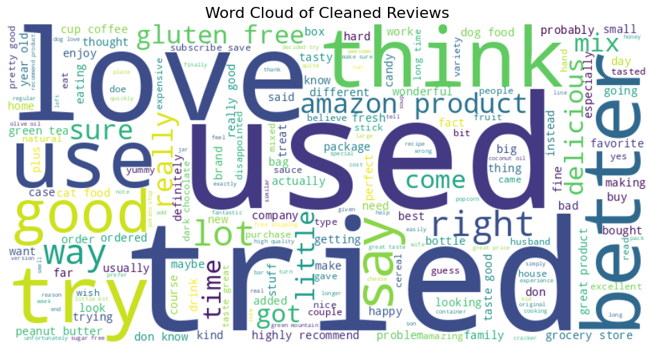

```python
all_words = " ".join(Review['cleaned_review'].astype(str))

wordcloud = WordCloud(
    width=800,
    height=400,
    background_color="white",
    colormap="viridis",
    max_words=200
).generate(all_words)


plt.figure(figsize=(12, 6))
plt.imshow(wordcloud, interpolation="bilinear")
plt.axis("off")
plt.title("Word Cloud of Cleaned Reviews", fontsize=16)
plt.show()
```

5. Perform N-gram Analysis on cleaned_review. a. Visualize the 20 most frequently occurring Bigrams and Trigrams.

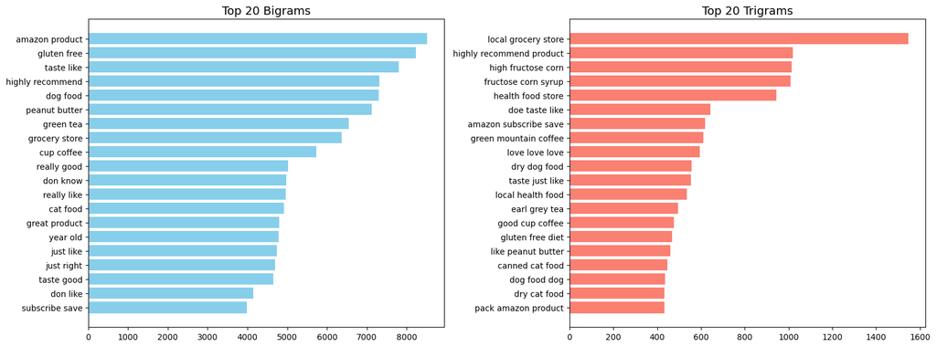

```python
bigram_vectorizer = CountVectorizer(ngram_range=(2, 2), stop_words="english")
bigram_matrix = bigram_vectorizer.fit_transform(Review["cleaned_review"])

bigram_freq = bigram_matrix.sum(axis=0).A1
bigram_terms = bigram_vectorizer.get_feature_names_out()

bigram_data = (
    pd.DataFrame({"Bigram": bigram_terms, "Count": bigram_freq})
    .sort_values("Count", ascending=False)
    .head(20)
)


trigram_vectorizer = CountVectorizer(ngram_range=(3, 3), stop_words="english")
trigram_matrix = trigram_vectorizer.fit_transform(Review["cleaned_review"])

trigram_freq = trigram_matrix.sum(axis=0).A1
trigram_terms = trigram_vectorizer.get_feature_names_out()

trigram_data = (
    pd.DataFrame({"Trigram": trigram_terms, "Count": trigram_freq})
    .sort_values("Count", ascending=False)
    .head(20)
)


fig, axes = plt.subplots(1, 2, figsize=(16, 6))


axes[0].barh(bigram_data["Bigram"], bigram_data["Count"], color="skyblue")
axes[0].set_title("Top 20 Bigrams", fontsize=14)
axes[0].invert_yaxis()

# Plot trigrams
axes[1].barh(trigram_data["Trigram"], trigram_data["Count"], color="salmon")
axes[1].set_title("Top 20 Trigrams", fontsize=14)
axes[1].invert_yaxis()

plt.tight_layout()
plt.show()
```

6. Creating two objects X and y. X will be the 'cleaned_review' column of Review dataframe and y will be the 'Score' column.

```python
X = Review['cleaned_review']
y = Review['Score']
```

a) Creating a TFIDF object and split the data into training and testing sets. Train a Decision tree model and display the confusion Matrix.

```
TF-IDF Accuracy: 0.7046230165710868

Classification Report (TF-IDF):

              precision    recall  f1-score   support

           1       0.56      0.56      0.56      5123
           2       0.44      0.38      0.41      2993
           3       0.44      0.40      0.42      4325
           4       0.49      0.45      0.47      8208
           5       0.81      0.85      0.83     36197

    accuracy                           0.70     56846
   macro avg       0.55      0.53      0.54     56846
weighted avg       0.70      0.70      0.70     56846
```

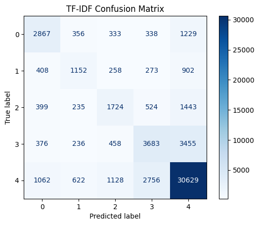

```python
tfidf = TfidfVectorizer(max_features=5000)
X_tfidf = tfidf.fit_transform(X)

X_train, X_test, y_train, y_test = train_test_split(
    X_tfidf, y, test_size=0.2, random_state=42
)

model_tfidf = DecisionTreeClassifier(random_state=42).fit(X_train, y_train)

y_pred_tfidf = model_tfidf.predict(X_test)

print("TF-IDF Accuracy:", accuracy_score(y_test, y_pred_tfidf))


print("\nClassification Report (TF-IDF):\n")
print(classification_report(y_test, y_pred_tfidf))

ConfusionMatrixDisplay(confusion_matrix(y_test, y_pred_tfidf)).plot(cmap="Blues")
plt.title("TF-IDF Confusion Matrix")
plt.show()
```

b) Creating a BoW object and split the data into training and testing sets. Train a Decision tree model and display the confusion Matrix.

```
BoW Accuracy: 0.7085986700911234

Classification Report (BoW):

              precision    recall  f1-score   support

           1       0.58      0.57      0.57      5123
           2       0.46      0.38      0.42      2993
           3       0.45      0.40      0.42      4325
           4       0.49      0.45      0.47      8208
           5       0.81      0.85      0.83     36197

    accuracy                           0.71     56846
   macro avg       0.56      0.53      0.54     56846
weighted avg       0.70      0.71      0.70     56846
```

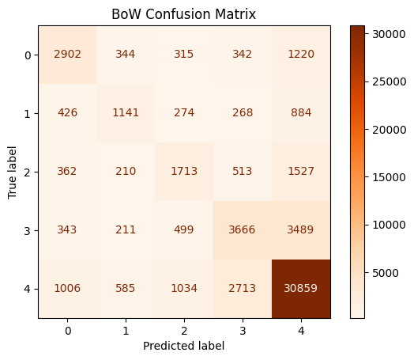

```python
bow = CountVectorizer(max_features=5000)
X_bow = bow.fit_transform(X)


X_train, X_test, y_train, y_test = train_test_split(
    X_bow, y, test_size=0.2, random_state=42
)

model_bow = DecisionTreeClassifier(random_state=42).fit(X_train, y_train)


y_pred_bow = model_bow.predict(X_test)

print("BoW Accuracy:", accuracy_score(y_test, y_pred_bow))

print("\nClassification Report (BoW):\n")
print(classification_report(y_test, y_pred_bow))

ConfusionMatrixDisplay(confusion_matrix(y_test, y_pred_bow)).plot(cmap="Oranges")
plt.title("BoW Confusion Matrix")
plt.show()
```

*c*) `Comparison TFIDF and BoW`

Results Comparison:

| Comparator | **TF-IDF** | **BoW** | **Better** |
| --- | --- | --- | --- |
| **Accuracy** | 0.7046 | 0.7086 | **BoW** |
| **Class 1 (Very Negative)** F1 | 0.56 | 0.57 | BoW |
| **Class 2 (Negative)** F1 | 0.41 | 0.42 | BoW |
| **Class 3 (Neutral)** F1 | 0.42 | 0.42 | Tie |
| **Class 4 (Positive)** F1 | 0.47 | 0.47 | Tie |
| **Class 5 (Very Positive)** F1 | 0.83 | 0.83 | Tie |
| **Macro Avg F1** | 0.54 | 0.54 | Tie |
| **Weighted Avg F1** | 0.70 | 0.70 | Tie (BoW recall slightly higher) |

| Feature | TF-IDF (Term Frequency–Inverse Document Frequency) | BoW (Bag of Words) |
| --- | --- | --- |
| **Weighting** | Assigns higher weight to rare but important words, lower weight to common words. | Treats all words equally, only counts frequency. |
| **Captures Importance** | Yes (considers global importance of words). | No (only considers local frequency in a document). |
| **Dimensionality** | Similar to BoW, but with weighted values. | High dimensional (sparse vectors). |
| **Handling Stopwords** | Naturally reduces influence of common words like “the”, “is”, etc. | Stopwords may dominate without manual removal. |
| **Interpretability** | Scores represent relevance of words in documents. | Easy to understand (just word counts). |
| **Model Performance** | Usually better for text classification tasks (less noise, more informative features). | May work well for simple tasks but less effective with large vocabularies. |
| **Computational Cost** | Slightly higher (needs IDF calculation). | Lower (just counts word frequencies). |
| **Use Case** | Best when importance of words matters (sentiment analysis, classification). | Best for simple frequency-based tasks (text clustering, keyword extraction). |

7. Implementing the HMM POS tagging on the first 2 rows of ‘cleaned_review’

```python
nltk.download("treebank")
nltk.download("universal_tagset")
nltk.download("punkt")
nltk.download("punkt_tab")


trainer = hmm.HiddenMarkovModelTrainer()
train_data = treebank.tagged_sents(tagset="universal")[:3000]
hmm_tagger = trainer.train_supervised(train_data)


for i in range(2):
    tokens = nltk.word_tokenize(Review['cleaned_review'].iloc[i])
    tagged = hmm_tagger.tag(tokens)
    print(f"Sentence {i+1} HMM POS tagging:\n", tagged, "\n")
```

```
Sentence 1 HMM POS tagging:
 [('tried', 'VERB'), ('couple', 'NOUN'), ('gluten', 'NOUN'), ('free', 'NOUN'), ('sandwich', 'NOUN'), ('best', 'NOUN'), ('bunch', 'NOUN'), ('crunchy', 'NOUN'), ('true', 'NOUN'), ('texture', 'NOUN'), ('real', 'NOUN'), ('gluten', 'NOUN'), ('free', 'NOUN'), ('think', 'NOUN'), ('filling', 'NOUN'), ('bit'…

Sentence 2 HMM POS tagging:
 [('cat', 'NOUN'), ('house', 'NOUN'), ('just', 'NOUN'), ('pop', 'NOUN'), ('come', 'NOUN'), ('treat', 'NOUN'), ('like', 'NOUN'), ('crunchy', 'NOUN'), ('perfect', 'NOUN'), ('given', 'NOUN'), ('like', 'NOUN'), ('equally', 'NOUN'), ('tend', 'NOUN'), ('dry', 'NOUN'), ('time', 'NOUN'), ('near', 'NOUN'), (…
```

8. Implementing the dependency parser for any two random sentences from the entire corpus/dataset that has at least 10 words in the sentence. Ensure the dependency parser looks good and is visually understandable.

```python
nlp = spacy.load("en_core_web_sm")


long_reviews = Review[Review['cleaned_review'].str.split().str.len() >= 10]['cleaned_review']
samples = random.sample(list(long_reviews), 2)

for idx, sent in enumerate(samples, 1):
    doc = nlp(sent)
    print(f"\nSentence {idx}: {sent}\n")

    displacy.render(
        doc,
        style="dep",
        jupyter=True,
        options={"distance": 120, "compact": True, "color": "blue", "bg": "white"}
    )


    dep_data = []
    for token in doc:
        dep_data.append({
            "Token": token.text,
            "POS": token.pos_,
            "Dependency": token.dep_,
            "Head": token.head.text
        })

    df = pd.DataFrame(dep_data)
    print(f"\nDependency Table for Sentence {idx}:\n")
    display(df)
```

```
Sentence 1: simple concept raw natural make moist delicious snack pecan pie cashew far try just ordered chocolate wait try
```

[figure not shown]

```
Dependency Table for Sentence 1:
```

|  | Token | POS | Dependency | Head |
| --- | --- | --- | --- | --- |
| 0 | simple | ADJ | amod | concept |
| 1 | concept | NOUN | nsubj | make |
| 2 | raw | ADJ | amod | make |
| 3 | natural | ADJ | amod | make |
| 4 | make | VERB | ccomp | ordered |
| 5 | moist | ADJ | amod | pie |
| 6 | delicious | ADJ | amod | pie |
| 7 | snack | NOUN | compound | pecan |
| 8 | pecan | PROPN | compound | pie |
| 9 | pie | NOUN | dobj | make |
| 10 | cashew | NOUN | advmod | make |
| 11 | far | ADV | advmod | make |
| 12 | try | AUX | aux | ordered |
| 13 | just | ADV | advmod | ordered |
| 14 | ordered | VERB | ROOT | ordered |
| 15 | chocolate | NOUN | compound | wait |
| 16 | wait | PROPN | dobj | ordered |
| 17 | try | NOUN | dobj | ordered |

```
Sentence 2: idea cold bottled coffee drink order starbuck going disappointed illy coffee drink don wrong fan starbuck frap don read list realize sugar milk probably come coffee illy touch sugar leaf doubt main ingredient coffee strong type coffee illy veteran coffee drinker probably like compare fre…
```

[figure not shown]

```
Dependency Table for Sentence 2:
```

|  | Token | POS | Dependency | Head |
| --- | --- | --- | --- | --- |
| 0 | idea | NOUN | compound | starbuck |
| 1 | cold | ADJ | amod | drink |
| 2 | bottled | ADJ | amod | coffee |
| 3 | coffee | NOUN | compound | drink |
| 4 | drink | NOUN | compound | order |
| ... | ... | ... | ... | ... |
| 74 | quickly | ADV | advmod | list |
| 75 | easily | ADV | advmod | high |
| 76 | illy | ADV | advmod | high |
| 77 | high | ADJ | amod | list |
| 78 | list | NOUN | dobj | realize |

79 rows × 4 columns

```python
    !jupyter nbconvert --to html /content/NLP_Assignment_2024ct05034.ipynb
```

[output not shown]

[output cut: 136 more lines]

[output not shown]